# Part II - Prosper Loan data - Borrower APR

## by Monique van den Berg

## Investigation Overview

In this investigation, I wanted to look at the features which would significanlty affect BorrowerAPR. The main focus was on the LoanOriginalAmount, ProsperScore and Term.

## Dataset Overview

The dataset contains 113,937 loans with 81 variables on each loan. The dataset contains information about the borrower, the loan and some risk metrics.

## Distribution of BorrowerAPR

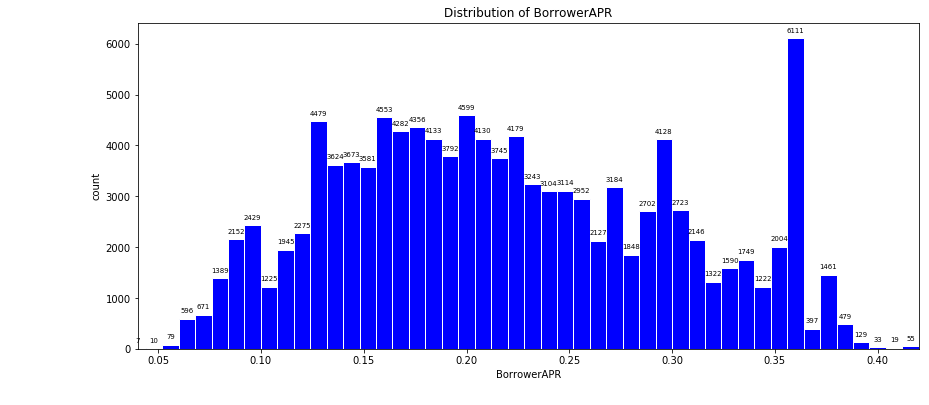

## Distribution of LoanOriginalAmount

The value of loans range from \$1000 - \\$35000. The distribution is skewed to the right, with most loans below a value of \$12000. Round numbers are popular with peaks at 2000, 3000, 4000, 5000, 10000, 15000, 20000 and 25000. The most popular loan amount is \\$4000.

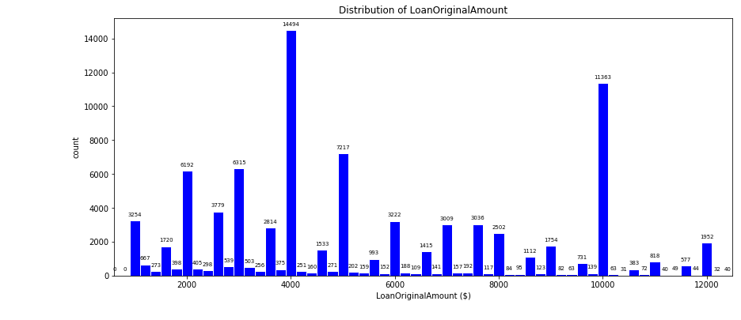

## BorrowerAPR vs LoanOriginalAmount

LoanOriginalAmount and BorrowerAPR are negatively correlated. A larger amount being borrowed results in a lower APR.

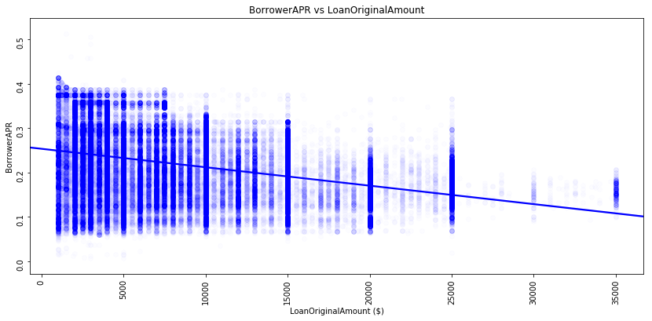

## BorrowerAPR vs. ProsperScore

ProsperScore can take on a value of 1 to 11 and the most popular prosper scores are 4, 6 and 8.

There is a negative relationship between BorrowerAPR and ProsperScore. A higher ProsperScore results in a lower APR.

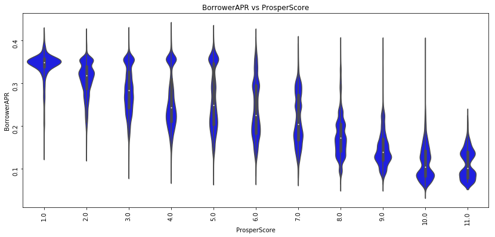

## BorrowerAPR vs LoanOriginalAmount by ProsperScore

As ProsperScore increases the negative correlation beween BorrowerAPR and LoanOriginalAmount decreases and travels through no correlation to finally end on positive correlation at a ProsperScore of 11.

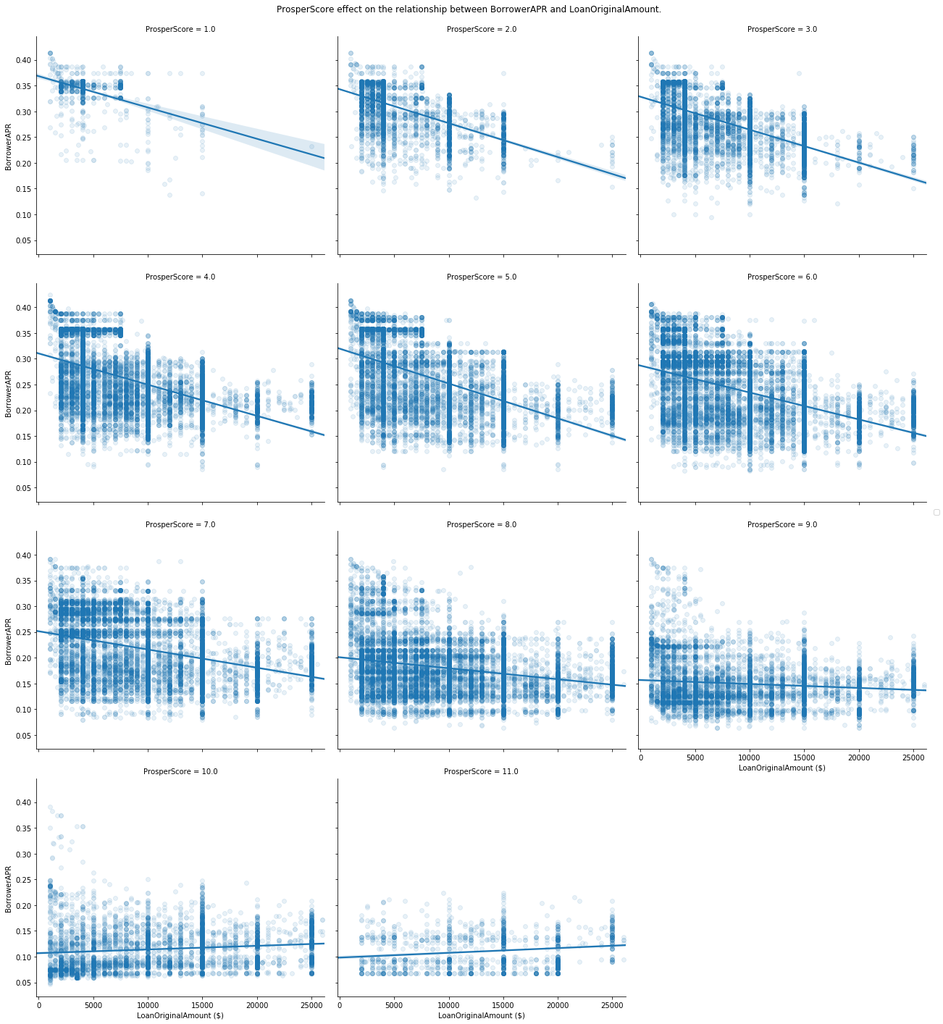

## BorrowerAPR vs LoanOriginalAmount by Term

There are three terms on which money is borrowed, 12, 36 or 60 months. 36 months is the most popular term. Term and BorrowerAPR has no correlation.

As term increases the offset value of BorrowerAPR increaes while the negative relationship betweem BorrowerAPR and LoanOriginalAmount remaines the same.

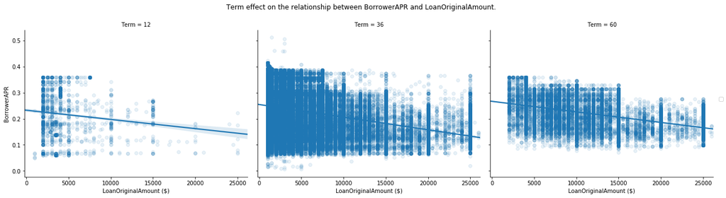

## BorrowerAPR by ProsperScore and Term

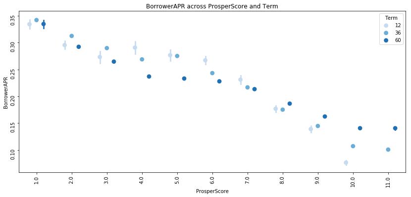